# PS5 Template

Jacob Rodriguez

2/19/2023

# Disclaimer: this serves as a template for you to compose your answer for PS4. It is 100% hardcoded, so error may exists. Please refer to the official spec for a full list of questions and requirements.

# Instructions

This is a problem set about rmarkdown and plotting (using ggplot). Unlike the previous problem sets, this one does not give you a ready-made GH repo with a code file–it is now your task to create a repo and include your rmarkdown file in there.

You should answer the questions below in that file, knit it, and submit both the compiled html and link to your repo on canvas.

- This problem sets asks you to write extensively when commenting your results. Please write clearly! Answer questions in a way that if the code chunks are hidden then the result is still readable!
  - All substantial questions need explanations. You do not have to explain the simple things like “how many rows are there in data”, but if you make a plot of life expectancy, then you should explain what does the plot tell you.
  - Write explanations as markdown and use the styles like bold and italic as appropriate.
- Do not print too much results. It is all well to print a few lines of data for evaluation/demonstration purposes. But do not print dozens (or thousands!) of lines–no one bothers to look at that many numbers. You will lose points for annoying others (here your graders, but later potentially your boss).
- Do not make code lines too long. 80-100 characters is a good choice. Your grader may not be able to follow all the code if the line is too long–most of us are using small laptop screens! (And again–you want to keep your graders happy!)

# Gapminder data

We use gapminder dataset, downloaded from [**https://www.gapminder.org/data/**](https://www.gapminder.org/data/), however, the data structure there is quire complex, please use the dataset provided on canvas (in files/data).  
The variables are:  
**name** country name  
**iso3** 3-letter country code  
**iso2** 2-letter country code  
**region** broad geographic region  
**sub-region** more precise region  
**intermediate-region**  
**time** year  
**totalPopulation** total population  
**GDP_PC** GDP per capita (constant 2010 US$)  
**accessElectricity** Access to electricity (% of population)  
**agriculturalLand** Agricultural land (sq. km)  
**agricultureTractors** Agricultural machinery, tractors (count)  
**cerealProduction** Cereal production (metric tons)  
**feritilizerHa** Fertilizer consumption (kilograms per hectare of arable land)  
**fertilityRate** total fertility rate (births per woman)  
**lifeExpectancy** Life expectancy at birth, total (years)  
**childMortality** Mortality rate, under-5 (per 1,000 live births)  
**youthFemaleLiteracy** Literacy rate, youth female (% of females ages 15-24)  
**youthMaleLiteracy** Literacy rate, youth male (% of males ages 15-24)  
**adultLiteracy** Literacy rate, adult total (% of people ages 15 and above)  
**co2** CO2 emissions (kt)  
**greenhouseGases** Total greenhouse gas emissions (kt of CO2 equivalent)  
**co2_PC** CO2 emissions (metric tons per capita)  
**pm2.5_35** PM2.5 pollution, population exposed to levels exceeding WHO Interim Target-1 value 36ug/m3  
**battleDeaths** Battle-related deaths (number of people)

# 1 Load and check data (5pt)

You first task is to do a very simple data check:

1. (1pt) For solving the problems, and answering the questions, create a new rmarkdown document with an appropriate title. See [**https://faculty.washington.edu/otoomet/info201-book/r-markdown.html#r-markdown-rstudio-creating**](https://faculty.washington.edu/otoomet/info201-book/r-markdown.html#r-markdown-rstudio-creating).

```r
library(tidyverse)
getwd()
```

```
## [1] "/Users/jacobrodriguez/Info201/ps5"
```

2. (2pt) Load data. How many rows/columns do we have?

```r
gapmind <- read_delim("gapminder.csv.bz2")
ncol(gapmind) ##Number of columns which is 25
```

```
## [1] 25
```

```r
nrow(gapmind) ##Number of rows which is 13055
```

```
## [1] 13055
```

3. (2pt) Print a small sample of data. Does it look OK?

```r
head(gapmind)
```

```
## # A tibble: 6 × 25
##   iso3  name  iso2  region sub-r…¹ inter…²  time total…³ ferti…⁴ lifeE…⁵ child…⁶
##   <chr> <chr> <chr> <chr>  <chr>   <chr>   <dbl>   <dbl>   <dbl>   <dbl>   <dbl>
## 1 ABW   Aruba AW    Ameri… Latin … Caribb…  1960   54211    4.82    65.7      NA
## 2 ABW   Aruba AW    Ameri… Latin … Caribb…  1961   55438    4.66    66.1      NA
## 3 ABW   Aruba AW    Ameri… Latin … Caribb…  1962   56225    4.47    66.4      NA
## 4 ABW   Aruba AW    Ameri… Latin … Caribb…  1963   56695    4.27    66.8      NA
## 5 ABW   Aruba AW    Ameri… Latin … Caribb…  1964   57032    4.06    67.1      NA
## 6 ABW   Aruba AW    Ameri… Latin … Caribb…  1965   57360    3.84    67.4      NA
## # … with 14 more variables: youthFemaleLiteracy <dbl>, youthMaleLiteracy <dbl>,
## #   adultLiteracy <dbl>, GDP_PC <dbl>, accessElectricity <dbl>,
## #   agriculturalLand <dbl>, agricultureTractors <dbl>, cerealProduction <dbl>,
## #   fertilizerHa <dbl>, co2 <dbl>, greenhouseGases <dbl>, co2_PC <dbl>,
## #   pm2.5_35 <dbl>, battleDeaths <dbl>, and abbreviated variable names
## #   ¹`sub-region`, ²`intermediate-region`, ³totalPopulation, ⁴fertilityRate,
## #   ⁵lifeExpectancy, ⁶childMortality
```

# 2 Descriptive statistics (15pt)

1. (3pt) How many countries are there in the dataset? Analyze all three: *iso3*, *iso2* and *name*.

```r
gapmind %>%
  summarise(names = n_distinct(name),
            ISO2 = n_distinct(iso2),
            ISO3 = n_distinct(iso3))
```

```
## # A tibble: 1 × 3
##   names  ISO2  ISO3
##   <int> <int> <int>
## 1   250   249   253
```

```r
names <- gapmind %>%
  filter(iso2 %in% gapmind$iso2) %>%
  distinct(iso2, name)
names
```

```
## # A tibble: 250 × 2
##    iso2  name
##    <chr> <chr>
##  1 AW    Aruba
##  2 AF    Afghanistan
##  3 AO    Angola
##  4 AI    Anguilla
##  5 AX    Åland Islands
##  6 AL    Albania
##  7 AD    Andorra
##  8 AE    United Arab Emirates
##  9 AR    Argentina
## 10 AM    Armenia
## # … with 240 more rows
```

```
(b) (5pt) Now repeat the same for name and iso3-code. Are there country names that have more than one iso3-code? What are these countries? Hint: two of these entitites are *CHANISL* and *NLD CURACAO*.
```

```r
how_many <- gapmind %>%
  filter(iso3 %in% gapmind$iso3) %>%
  distinct(iso3, name)
how_many
```

```
## # A tibble: 253 × 2
##    iso3  name
##    <chr> <chr>
##  1 ABW   Aruba
##  2 AFG   Afghanistan
##  3 AGO   Angola
##  4 AIA   Anguilla
##  5 ALA   Åland Islands
##  6 ALB   Albania
##  7 AND   Andorra
##  8 ARE   United Arab Emirates
##  9 ARG   Argentina
## 10 ARM   Armenia
## # … with 243 more rows
```

3. (2pt) What is the minimum and maximum year in these data?

```r
# Find maximum and minimum years
max_year <- max(gapmind$time, na.rm = TRUE)
min_year <- min(gapmind$time, na.rm = TRUE)
max_year
```

```
## [1] 2019
```

```r
min_year
```

```
## [1] 1960
```

# 3 CO2 emissions (30pt)

Next, let’s analyze CO2 emissions.

1. (2pt) How many missing co2 emissions are there for each year? Analyze both missing *CO2* and *co2_PC*. Which years have most missing data?

```r
##finds the missing co2 and cos_PC values for each year
missing_co2 <- table(is.na(gapmind$co2), gapmind$time)
missing_co2
```

```
##
##         1960 1961 1962 1963 1964 1965 1966 1967 1968 1969 1970 1971 1972 1973
##   FALSE  156  157  159  160  166  166  166  166  166  166  167  168  169  169
##   TRUE    60   60   58   57   51   51   51   51   51   51   50   49   48   48
##
##         1974 1975 1976 1977 1978 1979 1980 1981 1982 1983 1984 1985 1986 1987
##   FALSE  169  169  169  169  169  169  169  169  169  169  169  169  169  169
##   TRUE    48   48   48   48   48   48   48   48   48   48   48   48   48   48
##
##         1988 1989 1990 1991 1992 1993 1994 1995 1996 1997 1998 1999 2000 2001
##   FALSE  169  169  176  177  198  198  199  199  199  199  199  199  199  199
##   TRUE    48   48   41   40   19   19   18   18   18   18   18   18   18   18
##
##         2002 2003 2004 2005 2006 2007 2008 2009 2010 2011 2012 2013 2014 2015
##   FALSE  200  200  200  201  202  203  204  204  204  204  207  207  207  204
##   TRUE    17   17   17   16   15   14   13   13   13   13   10   10   10   13
##
##         2016 2017 2018 2019
##   FALSE  204    0    0    0
##   TRUE    13  217  217  217
```

```r
missing_co2_PC <- table(is.na(gapmind$co2_PC), gapmind$time)
missing_co2_PC
```

```
##
##         1960 1961 1962 1963 1964 1965 1966 1967 1968 1969 1970 1971 1972 1973
##   FALSE  156  157  159  160  166  166  166  166  166  166  167  168  169  169
##   TRUE    60   60   58   57   51   51   51   51   51   51   50   49   48   48
##
##         1974 1975 1976 1977 1978 1979 1980 1981 1982 1983 1984 1985 1986 1987
##   FALSE  169  169  169  169  169  169  169  169  169  169  169  169  169  169
##   TRUE    48   48   48   48   48   48   48   48   48   48   48   48   48   48
##
##         1988 1989 1990 1991 1992 1993 1994 1995 1996 1997 1998 1999 2000 2001
##   FALSE  169  169  176  177  197  197  198  199  199  199  199  199  199  199
##   TRUE    48   48   41   40   20   20   19   18   18   18   18   18   18   18
##
##         2002 2003 2004 2005 2006 2007 2008 2009 2010 2011 2012 2013 2014 2015
##   FALSE  200  200  200  201  202  203  204  204  204  204  207  207  207  204
##   TRUE    17   17   17   16   15   14   13   13   13   13   10   10   10   13
##
##         2016 2017 2018 2019
##   FALSE  204    0    0    0
##   TRUE    13  217  217  217
```

```r
##fnds the years with the most missing data
co2_missing_rows <- which(is.na(gapmind$co2))
co2_missing_years <- table(gapmind$time[co2_missing_rows])
co2_missing_years <- sort(co2_missing_years, decreasing = TRUE)
head(co2_missing_years)
```

```
##
## 2017 2018 2019 1960 1961 1962
##  217  217  217   60   60   58
```

2. (5pt) Make a plot of total CO2 emissions over time for the U.S, China, and India. Add a few more countries of your choice. Explain what do you see.

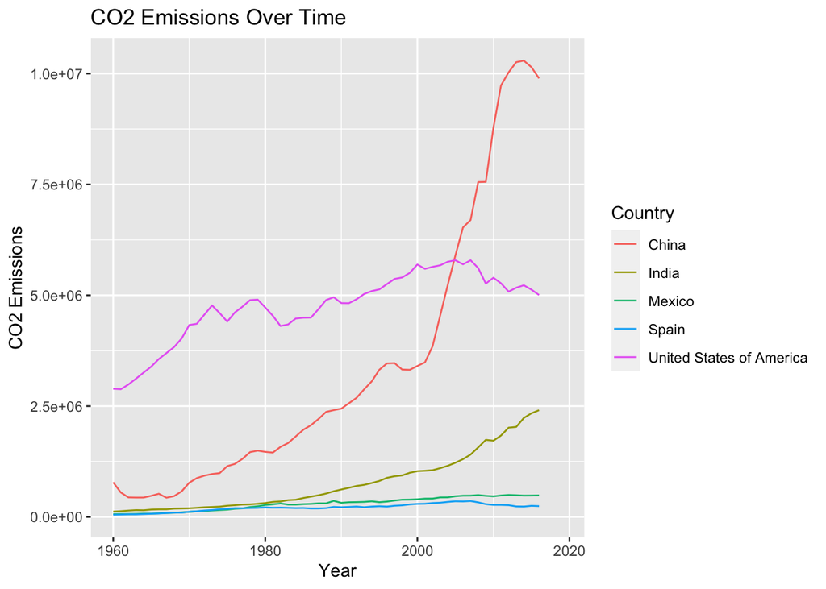

```r
countries <- c("United States of America", "China", "India", "Mexico", "Spain")
sub_data <- gapmind[gapmind$name %in% countries, ]
ggplot(sub_data, aes(x = time, y = co2, color = name)) +
  geom_line() +
  labs(x = "Year", y = "CO2 Emissions", color = "Country") +
  ggtitle("CO2 Emissions Over Time")
```

What we see with the graph is China’s Co2 emissions have grown exponentially more quickly than other countries like Mexico and Spain, with the US being a close contender.

3. (5pt) Now let’s analyze the CO2 emissions per capita (*co2_PC*). Make a similar plot of the same countries. What does this figure suggest?

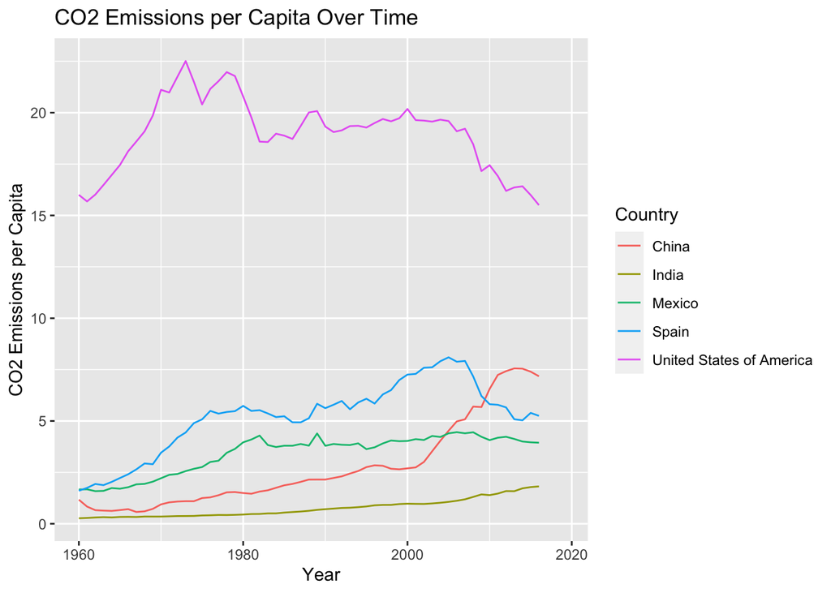

```r
countries <- c("United States of America", "China", "India", "Mexico", "Spain")
subgap <- gapmind[gapmind$name %in% countries, ]
ggplot(subgap, aes(x = time, y = co2_PC, color = name)) +
  geom_line() +
  labs(x = "Year", y = "CO2 Emissions per Capita", color = "Country") +
  ggtitle("CO2 Emissions per Capita Over Time")
```

The figure suggests that per capita emissions in the US is much higher than in China as the previous graph suggests.

4. (6pt) Compute average CO2 emissions per capita across the continents (assume *region* is the same as continent). Comment what do you see.  
   Note: just compute averages over countries and ignore the fact that countries are of different size.  
   Hint: Americas 2016 should be 4.80.

```r
gapmind %>%
  filter(time == 2016) %>%
  group_by(region) %>%
  summarize(avg_co2 = mean(co2_PC, na.rm = TRUE))
```

```
## # A tibble: 6 × 2
##   region   avg_co2
##   <chr>      <dbl>
## 1 Africa      1.20
## 2 Americas    4.80
## 3 Asia        6.47
## 4 Europe      6.64
## 5 Oceania     4.57
## 6 <NA>       19.4
```

5. (7pt) Make a barplot where you show the previous results–average CO2 emissions per capita across continents in 1960 and 2016. Hint: it should look something along these lines(**Please refer to the spec for the graph**)

```r
co2_per_year <- gapmind %>%
  filter(time == 1960 | time == 2016, !is.na(co2_PC), !is.na(region)) %>%
  group_by(time, region) %>%
  summarize(avg_co2 = mean(co2_PC, na.rm = TRUE))
```

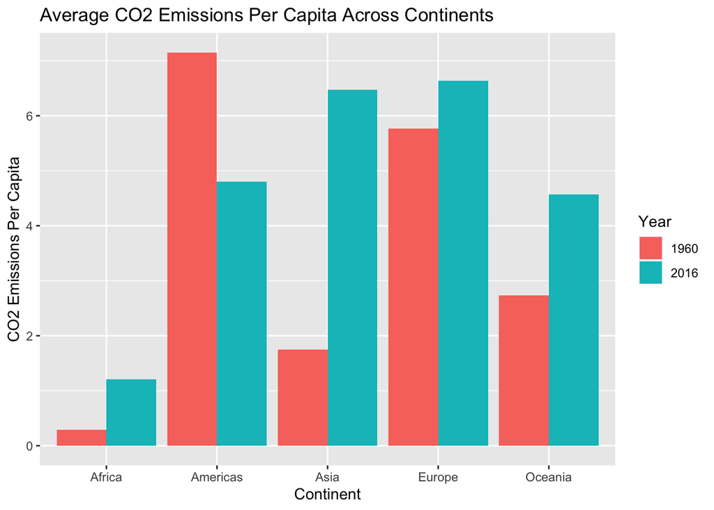

```r
ggplot(co2_per_year, aes(x = region, y = avg_co2, fill = as.factor(time))) +
  geom_col(position = "dodge") +
  labs(title = "Average CO2 Emissions Per Capita Across Continents", x = "Continent", y = "CO2 Emissions Per Capita") +
  scale_fill_discrete(name = "Year")
```

6. Which countries are the three largest, and three smallest CO2 emitters (in terms of CO2 per capita) in 2019 for each continent? (Assume *region* is continent).

```r
gapmind_2016 <- gapmind %>%
  filter(time == 2016)
top_3 <- gapmind_2016 %>%
  group_by(region) %>%
  top_n(3, co2_PC) %>%
  arrange(region, desc(co2_PC))
bottom_3 <- gapmind_2016 %>%
  group_by(region) %>%
  top_n(-3, co2_PC) %>%
  arrange(region, co2_PC)

print(top_3)
```

```
## # A tibble: 17 × 25
## # Groups:   region [6]
##    iso3        name   iso2  region sub-r…¹ inter…²  time total…³ ferti…⁴ lifeE…⁵
##    <chr>       <chr>  <chr> <chr>  <chr>   <chr>   <dbl>   <dbl>   <dbl>   <dbl>
##  1 ZAF         South… ZA    Africa Sub-Sa… Southe…  2016  5.62e7    2.46    63.2
##  2 LBY         Libya  LY    Africa Northe… <NA>     2016  6.49e6    2.32    72.3
##  3 SYC         Seych… SC    Africa Sub-Sa… Easter…  2016  9.47e4    2.39    74.3
##  4 TTO         Trini… TT    Ameri… Latin … Caribb…  2016  1.38e6    1.75    73.1
##  5 USA         Unite… US    Ameri… Northe… <NA>     2016  3.23e8    1.82    78.5
##  6 CAN         Canada CA    Ameri… Northe… <NA>     2016  3.61e7    1.54    81.9
##  7 QAT         Qatar  QA    Asia   Wester… <NA>     2016  2.65e6    1.91    79.9
##  8 KWT         Kuwait KW    Asia   Wester… <NA>     2016  3.96e6    2.08    75.2
##  9 BHR         Bahra… BH    Asia   Wester… <NA>     2016  1.43e6    2.03    76.9
## 10 GIB         Gibra… GI    Europe Southe… <NA>     2016  3.37e4   NA       NA
## 11 LUX         Luxem… LU    Europe Wester… <NA>     2016  5.82e5    1.41    82.7
## 12 FRO         Faroe… FO    Europe Northe… <NA>     2016  4.82e4    2.6     82.0
## 13 NCL         New C… NC    Ocean… Melane… <NA>     2016  2.77e5    2.08    76.9
## 14 AUS         Austr… AU    Ocean… Austra… <NA>     2016  2.42e7    1.75    82.4
## 15 PLW         Palau  PW    Ocean… Micron… <NA>     2016  1.77e4   NA       NA
## 16 NLD_CURACAO <NA>   <NA>  <NA>   <NA>    <NA>     2016  1.60e5    1.7     77.7
## 17 KOS         <NA>   <NA>  <NA>   <NA>    <NA>     2016  1.78e6    2.06    71.7
## # … with 15 more variables: childMortality <dbl>, youthFemaleLiteracy <dbl>,
## #   youthMaleLiteracy <dbl>, adultLiteracy <dbl>, GDP_PC <dbl>,
## #   accessElectricity <dbl>, agriculturalLand <dbl>, agricultureTractors <dbl>,
## #   cerealProduction <dbl>, fertilizerHa <dbl>, co2 <dbl>,
## #   greenhouseGases <dbl>, co2_PC <dbl>, pm2.5_35 <dbl>, battleDeaths <dbl>,
## #   and abbreviated variable names ¹`sub-region`, ²`intermediate-region`,
## #   ³totalPopulation, ⁴fertilityRate, ⁵lifeExpectancy
```

```r
print(bottom_3)
```

```
## # A tibble: 17 × 25
## # Groups:   region [6]
##    iso3        name   iso2  region sub-r…¹ inter…²  time total…³ ferti…⁴ lifeE…⁵
##    <chr>       <chr>  <chr> <chr>  <chr>   <chr>   <dbl>   <dbl>   <dbl>   <dbl>
##  1 COD         Congo… CD    Africa Sub-Sa… Middle…  2016  7.88e7    6.11    59.7
##  2 SOM         Somal… SO    Africa Sub-Sa… Easter…  2016  1.42e7    6.26    56.3
##  3 BDI         Burun… BI    Africa Sub-Sa… Easter…  2016  1.05e7    5.60    60.5
##  4 HTI         Haiti  HT    Ameri… Latin … Caribb…  2016  1.08e7    3.04    62.9
##  5 NIC         Nicar… NI    Ameri… Latin … Centra…  2016  6.30e6    2.46    73.9
##  6 HND         Hondu… HN    Ameri… Latin … Centra…  2016  9.27e6    2.54    74.7
##  7 AFG         Afgha… AF    Asia   Southe… <NA>     2016  3.54e7    4.8     63.8
##  8 NPL         Nepal  NP    Asia   Southe… <NA>     2016  2.73e7    2.03    69.8
##  9 YEM         Yemen  YE    Asia   Wester… <NA>     2016  2.72e7    3.99    66.1
## 10 LIE         Liech… LI    Europe Wester… <NA>     2016  3.77e4    1.61    82.3
## 11 ALB         Alban… AL    Europe Southe… <NA>     2016  2.88e6    1.66    78.2
## 12 MDA         Moldo… MD    Europe Easter… <NA>     2016  2.80e6    1.26    71.6
## 13 SLB         Solom… SB    Ocean… Melane… <NA>     2016  6.19e5    4.45    72.4
## 14 VUT         Vanua… VU    Ocean… Melane… <NA>     2016  2.78e5    3.86    70.0
## 15 KIR         Kirib… KI    Ocean… Micron… <NA>     2016  1.13e5    3.65    67.6
## 16 KOS         <NA>   <NA>  <NA>   <NA>    <NA>     2016  1.78e6    2.06    71.7
## 17 NLD_CURACAO <NA>   <NA>  <NA>   <NA>    <NA>     2016  1.60e5    1.7     77.7
## # … with 15 more variables: childMortality <dbl>, youthFemaleLiteracy <dbl>,
## #   youthMaleLiteracy <dbl>, adultLiteracy <dbl>, GDP_PC <dbl>,
## #   accessElectricity <dbl>, agriculturalLand <dbl>, agricultureTractors <dbl>,
## #   cerealProduction <dbl>, fertilizerHa <dbl>, co2 <dbl>,
## #   greenhouseGases <dbl>, co2_PC <dbl>, pm2.5_35 <dbl>, battleDeaths <dbl>,
## #   and abbreviated variable names ¹`sub-region`, ²`intermediate-region`,
## #   ³totalPopulation, ⁴fertilityRate, ⁵lifeExpectancy
```

## The data from 2017-2019 does not work for this section so I changed it to 2016

# 4 GDP per capita (50pt)

Let’s look at GDP per capita (*GDP_PC*)

1. (8pt) Make a scatterplot of GDP per capita versus life expectancy by country, using data for 1960. Make the point size dependent on the country size, and color those according to the continent. Feel free to adjust the plot in other ways to make it better Comment what do you see there

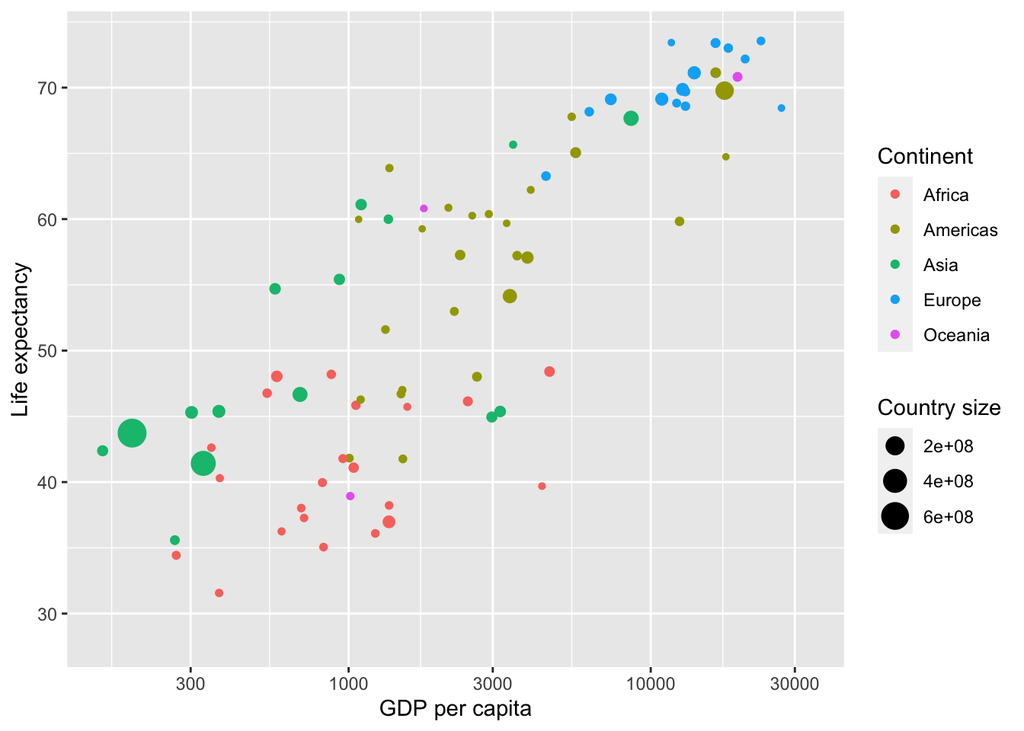

```r
gapmind_1960 <- gapmind %>% filter(time == 1960,!is.na(co2_PC), !is.na(region))


ggplot(gapmind_1960, aes(x = GDP_PC, y = lifeExpectancy, size = totalPopulation, color = region)) +
  geom_point() +
  scale_x_log10() +
  labs(x = "GDP per capita", y = "Life expectancy", size = "Country size", color = "Continent")
```

What we see here is that the life expectancy goes up the with higher GDP and the populations are different according to this and this is seen with sorther life expectancies for countries in Asia and Africa during the 1960s.

2. (4pt) Make a similar plot, but this time use 2019 data only.

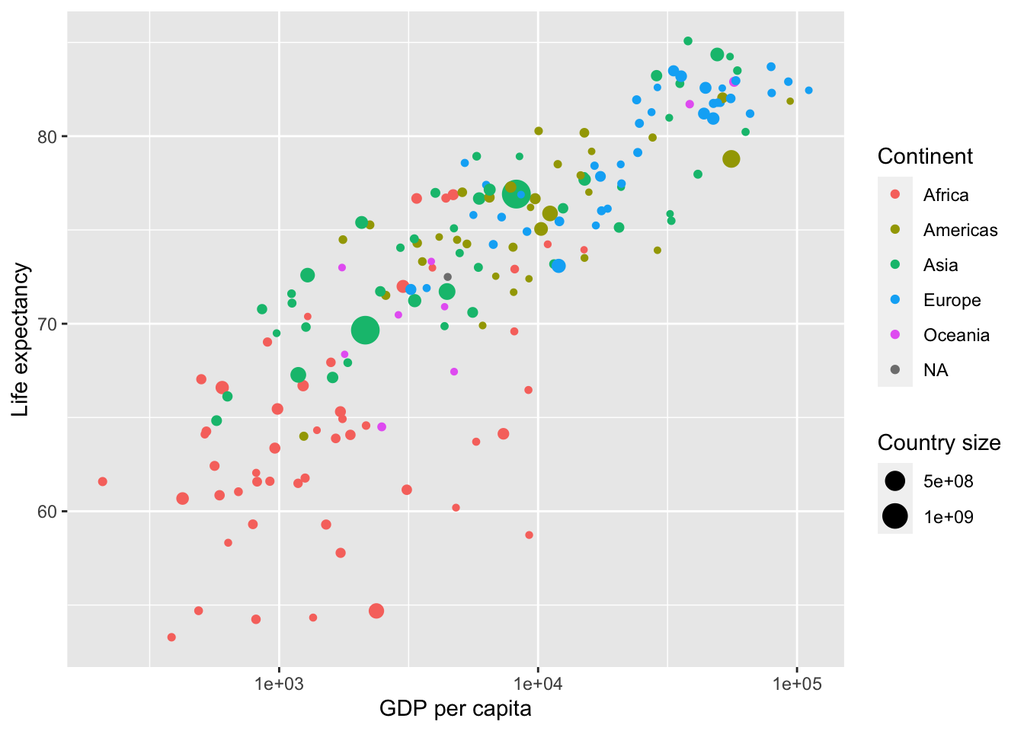

```r
gapmind_2019 <- gapmind %>% filter(time == 2019)


ggplot(gapmind_2019, aes(x = GDP_PC, y = lifeExpectancy, size = totalPopulation, color = region)) +
  geom_point() +
  scale_x_log10() +
  labs(x = "GDP per capita", y = "Life expectancy", size = "Country size", color = "Continent")
```

3. (6pt) Compare these two plots and comment what do you see. How has world developed through the last 60 years?

4. (6pt) Compute the average life expectancy for each continent in 1960 and 2019. Do the results fit with what do you see on the figures?  
   Note: here as *average*I mean just average over countries, ignore the fact that countries are of different size.

```r
gapmind_1960 %>%
  group_by(region) %>%
  summarize(Life_exp_1960 = mean(lifeExpectancy, na.rm = TRUE))
```

```
## # A tibble: 5 × 2
##   region   Life_exp_1960
##   <chr>            <dbl>
## 1 Africa            41.1
## 2 Americas          58.1
## 3 Asia              51.7
## 4 Europe            69.2
## 5 Oceania           58.0
```

```r
gapmind_2019 %>%
  group_by(region) %>%
  summarize(Life_exp_2019 = mean(lifeExpectancy, na.rm = TRUE))
```

```
## # A tibble: 6 × 2
##   region   Life_exp_2019
##   <chr>            <dbl>
## 1 Africa            64.1
## 2 Americas          75.8
## 3 Asia              74.6
## 4 Europe            79.4
## 5 Oceania           73.5
## 6 <NA>              77.8
```

5. (8pt) Compute the average LE growth from 1960-2019 across the continents. Show the results in the order of growth. Explain what do you see.  
   Hint: these data (data in long form) is not the simplest to compute growth. But you may want to check out the lag() function. And do not forget to group data by continent when using lag(), otherwise your results will be messed up! See [**https://faculty.washington.edu/otoomet/info201-book/dplyr.html#dplyr-helpers-compute**](https://faculty.washington.edu/otoomet/info201-book/dplyr.html#dplyr-helpers-compute).

```r
avg_growth <- gapmind_1960 %>%
  left_join(gapmind_2019, by = c("name", "region")) %>%
  mutate(le_growth = lifeExpectancy.y - lifeExpectancy.x) %>%
  group_by(region) %>%
  summarize(avg_le_growth = mean(le_growth, na.rm = TRUE)) %>%
  arrange(avg_le_growth, increasing = TRUE)

# Show the results in the order of growth
avg_growth
```

```
## # A tibble: 5 × 2
##   region   avg_le_growth
##   <chr>            <dbl>
## 1 Europe            11.5
## 2 Oceania           16.4
## 3 Americas          17.2
## 4 Africa            23.2
## 5 Asia              23.2
```

What we see here is that the different regions life expectancy went up and in regions such as Asia and Africa it going up by 23 years while in Europe only by 11 years.

6. (6pt) Show the histogram of GDP per capita for years of 1960 and 2019. Try to put both histograms on the same graph, see how well you can do it!

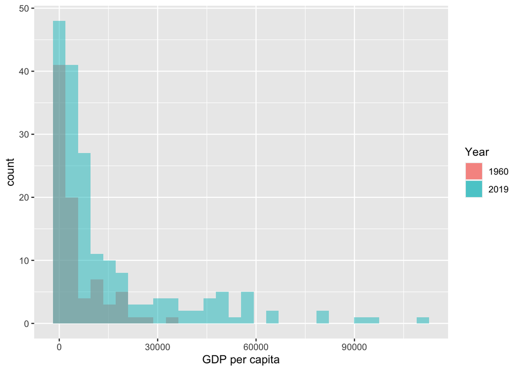

```r
ggplot() +
  geom_histogram(data = gapmind_1960, aes(x = GDP_PC, fill = "1960"), alpha = 0.5) +
  geom_histogram(data = gapmind_2019, aes(x = GDP_PC, fill = "2019"), alpha = 0.5) +
  # Set axis labels and legend title
  labs(x = "GDP per capita", fill = "Year")
```

7. (6pt) What was the ranking of US in terms of life expectancy in 1960 and in 2019? (When counting from top.)  
   Hint: check out the function rank()!  
   Hint2: 17 for 1960.

```r
us_rank <- gapmind %>%
  filter(time == 1960 | time == 2019) %>%
  group_by(time) %>%
  mutate(lifeExp_rank = rank(lifeExpectancy))


us_rank_1960 <- us_rank %>%
  filter(time == 1960 & name == "United States of America") %>%
  pull(lifeExp_rank)

us_rank_2019 <- us_rank %>%
  filter(time == 2019 & name == "United States of America") %>%
  pull(lifeExp_rank)

us_rank_1960
```

```
## [1] 172
```

```r
us_rank_2019
```

```
## [1] 152
```

8. (6pt) If you did this correctly, then you noticed that US ranking has been falling quite a bit. But we also have more countries in 2019–what about the relative rank divided by the corresponding number of countries that have LE data in the corresponding year?  
   Hint: 0.0904 for 1960.

```r
gapmind %>%
  filter(time == 1960 | time == 2019) %>%
  group_by(time) %>%
  mutate(lifeExp_rank = dense_rank(desc(lifeExpectancy))) %>%
  group_by(time) %>%
  mutate(rel_lifeExp_rank = lifeExp_rank / n_distinct(name[!is.na(lifeExpectancy)])) %>%
  filter(name == "United States of America") %>%
  select(time, lifeExpectancy, lifeExp_rank, rel_lifeExp_rank)
```

```
## # A tibble: 2 × 4
## # Groups:   time [2]
##    time lifeExpectancy lifeExp_rank rel_lifeExp_rank
##   <dbl>          <dbl>        <int>            <dbl>
## 1  1960           69.8           18           0.0952
## 2  2019           78.8           47           0.239
```

Finally tell us how many hours did you spend on this PS.